# Practical 1: A control chart problem

## part a - summary of waiting times

```r
waiting <- read.csv(here::here("data/waiting.csv"))
```

*Graph* displays the daily waiting times period that the Data covers. It is difficult to notice any seasonality or cyclic patterns in the extreme waiting times.

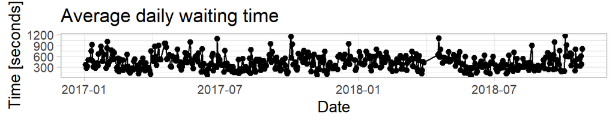

```r
waiting$Date <- as.Date(waiting$Date)

waiting %>%
  ggplot(aes(Date, Average.Wait.Seconds)) +
  geom_line() +
  geom_point() +
  labs (title = "Average daily waiting time",
        x = "Date",
        y = "Time [seconds]")
```

As shown on *graph* and on *table*, Monday, Tuesday and Wednesday are the days of the week tht present the highests extreme values. We can also notice that even if Friday has the highest average waiting time, its maximum value is the lowest.

```r
waiting %>%
  mutate(Weekday=factor(Weekday, levels= c("Monday",
    "Tuesday", "Wednesday", "Thursday", "Friday"))) %>%
  group_by(Weekday) %>%
  summarize(Min = min(Average.Wait.Seconds),
             Q1 = quantile(Average.Wait.Seconds, .25),
             Avg = mean(Average.Wait.Seconds),
             Q3 = quantile(Average.Wait.Seconds, .75),
             Max = max(Average.Wait.Seconds)) %>%
  kable(caption = "Data summary") %>%
  kable_styling(bootstrap_options = c("striped", "hover"))
```

Data summary

| Weekday | Min | Q1 | Avg | Q3 | Max |
| --- | --- | --- | --- | --- | --- |
| Monday | 116 | 297 | 446 | 559 | 999 |
| Tuesday | 90 | 262 | 431 | 550 | 1154 |
| Wednesday | 95 | 293 | 471 | 597 | 1182 |
| Thursday | 81 | 217 | 373 | 487 | 938 |
| Friday | 148 | 342 | 485 | 622 | 918 |

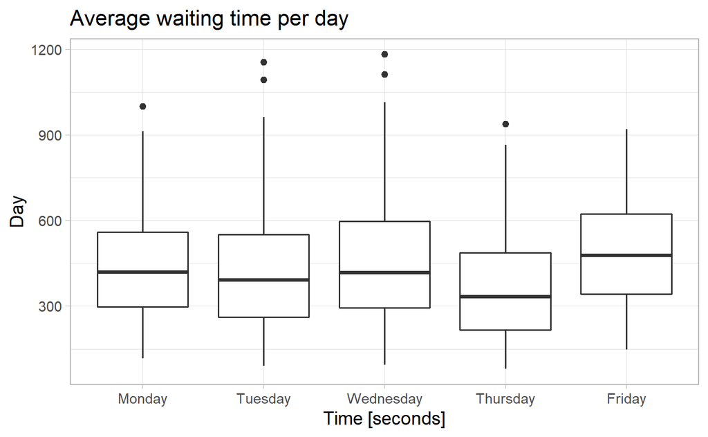

```r
waiting %>%
  mutate(Weekday=factor(Weekday, levels= c("Monday",
    "Tuesday", "Wednesday", "Thursday", "Friday"))) %>%
  ggplot(aes(Average.Wait.Seconds, Weekday)) +
  geom_boxplot() +
  coord_flip() +
  labs (title = "Average waiting time per day",
        x = "Day",
        y = "Time [seconds]")
```

## part b - normal approximation

```r
n <- 250

p <- (1-(1/n))
```

As the one year period corresponds to
$$n = 250$$
, we can deduce the upper control limit, which corresponds to
$$p = 1-1/n$$
and equals to 0.996. After scaling this value, we can retrieve the associated quantile or the upper control limit.

```r
mean <- mean(waiting$Average.Wait.Seconds)
sd <- sd(waiting$Average.Wait.Seconds)

upper_limit <- qnorm(p, mean, sd)
upper_limit %>%
  kable(caption = "Upper Limit") %>%
  kable_styling(bootstrap_options = c("striped", "hover"))
```

Upper Limit

| x |
| --- |
| 987 |

The upper control limit corresponds to 987.472.

*Graph* suggest that the normal distribution is not appropriate to predict extreme values, the extreme observations tend to diverge strongly from their theorical values under the assumption of a normal distribution. This suggests that the tails are heavy.

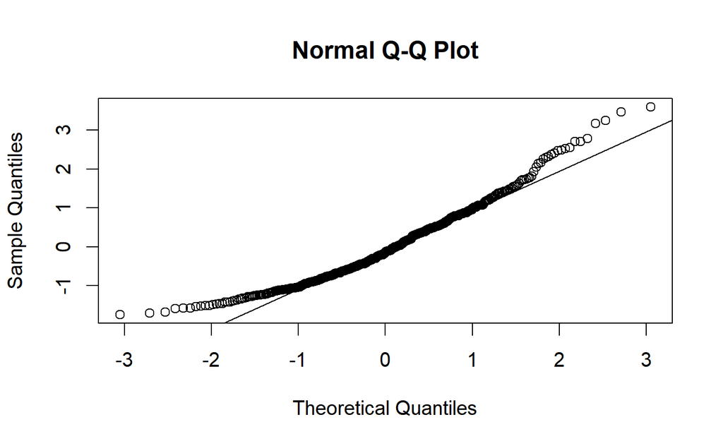

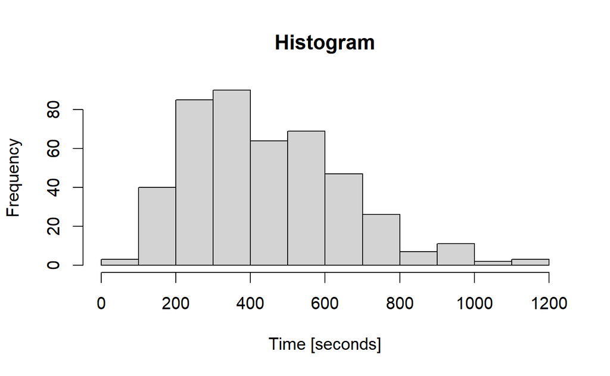

```r
qqnorm(scale(waiting$Average.Wait.Seconds))
qqline(scale(waiting$Average.Wait.Seconds))
hist(waiting$Average.Wait.Seconds, main = "Histogram", xlab = "Time [seconds]")
```

```r
shapiro <- shapiro.test(waiting$Average.Wait.Seconds)
```

Running the Shapiro-Wilk test shows that the hypothesis of normality is rejected at level 6.105^{-10}

## part c - analzying long waiting times

### Block Maxima

The Block Maxima approach divides the dataset into blocks with the same number of observations. Then, for each block we select the observation with the highest value. Looking at the dataset, we can divide it by months or on a weekly basis :

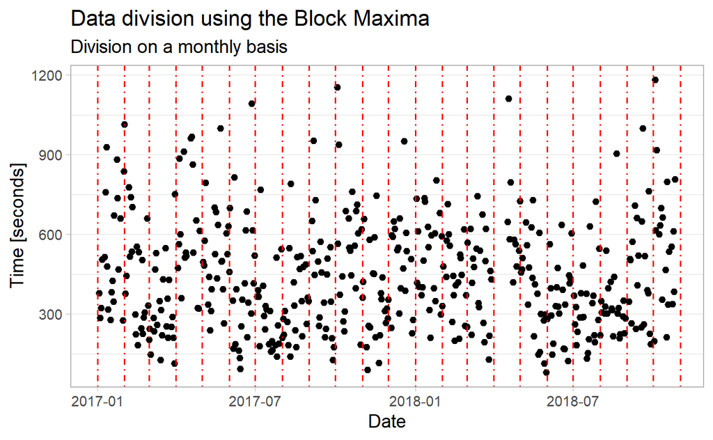

```r
plot_all_obs <-waiting %>%
  ggplot(aes(x = Date, y = Average.Wait.Seconds)) +
  geom_point()

tmp <- data.frame(x=rep(seq(as.Date(0, origin="2017-01-01"),
                            length=36, by="1 month"), 2),
                  y=rnorm(72),
                  category=gl(2,36))

plot_all_obs + geom_vline(xintercept=as.numeric(tmp$x),
                linetype=4, colour="red") + labs(x = "Date", y = "Time [seconds]", title = "Data division using the Block Maxima", subtitle = "Division on a monthly basis")
```

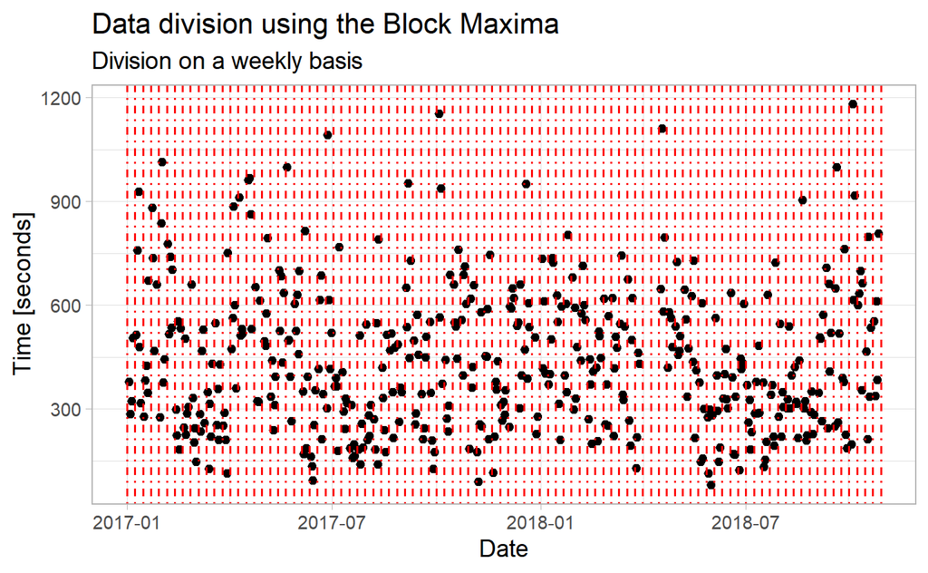

```r
# per week
tmp <- data.frame(x=rep(seq(as.Date(0, origin="2017-01-01"),
                            length=96, by="1 week"), 2))

plot_all_obs + geom_vline(xintercept=as.numeric(tmp$x),
                linetype=4, colour="red") + labs(x = "Date", y = "Time [seconds]", title = "Data division using the Block Maxima", subtitle = "Division on a weekly basis")
```

Looking at the data aggregation per month and week, we can say that the first seems to be better. However in order to confirm this hypothesis, when modelling we are going to analyse both cases and keep the model that provides the best results. For the models, we are going to fit a GEV functin on the maxima of each block, represented by the red dots in the following plots.

```r
maxima_monthly <- waiting %>%
  group_by(year(ymd(Date)), month(ymd(Date))) %>%
  filter(Average.Wait.Seconds == max(Average.Wait.Seconds))

maxima_weekly <- waiting %>%
  group_by(year(ymd(Date)), week(ymd(Date))) %>%
  filter(Average.Wait.Seconds == max(Average.Wait.Seconds))
```

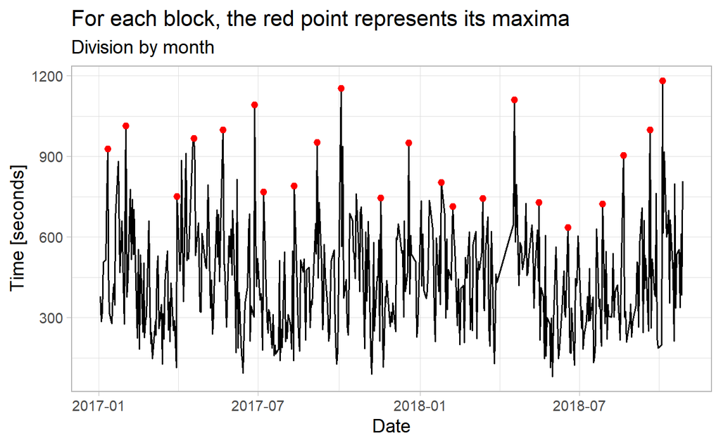

```r
waiting %>%
  ggplot(aes(Date, Average.Wait.Seconds)) +
  geom_line() +
  geom_point(aes(Date, Average.Wait.Seconds), data = maxima_monthly, color = "red") +
  labs (x = "Date",
        y = "Time [seconds]",
        title = "For each block, the red point represents its maxima",
        subtitle = "Division by month")
```

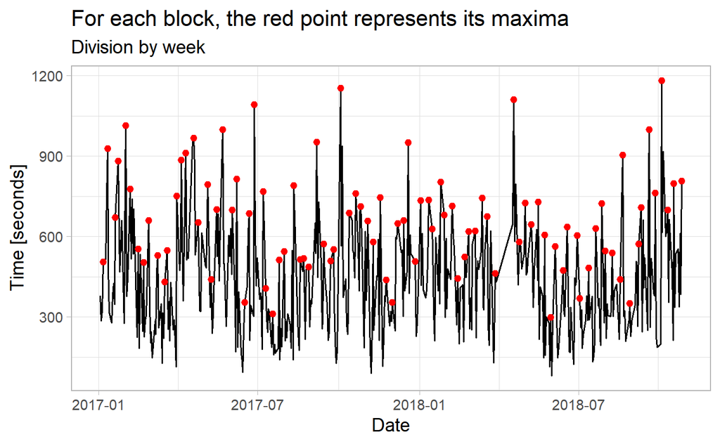

```r
waiting %>%
  ggplot(aes(Date, Average.Wait.Seconds)) +
  geom_line() +
  geom_point(aes(Date, Average.Wait.Seconds), data = maxima_weekly, color = "red") +
  labs (x = "Date",
        y = "Time [seconds]",
        title = "For each block, the red point represents its maxima",
        subtitle = "Division by week")
```

### Peaks-over-threshold approach

The Peaks-over-threshold approach defines the extreme values as the observations above a certain threshold u. In order to find this threshold, we can use an mrlplot and the tcplot.

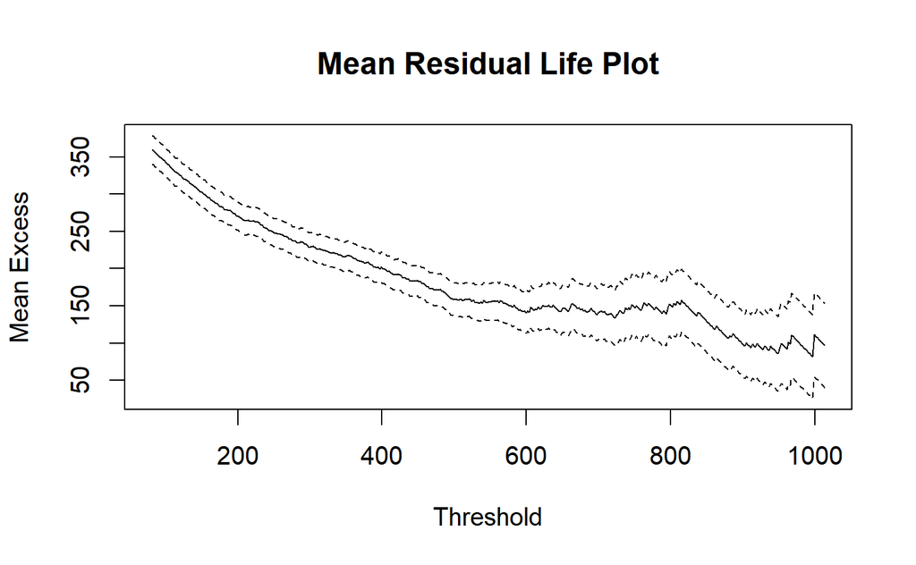

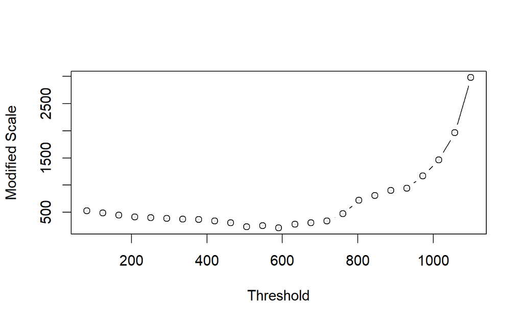

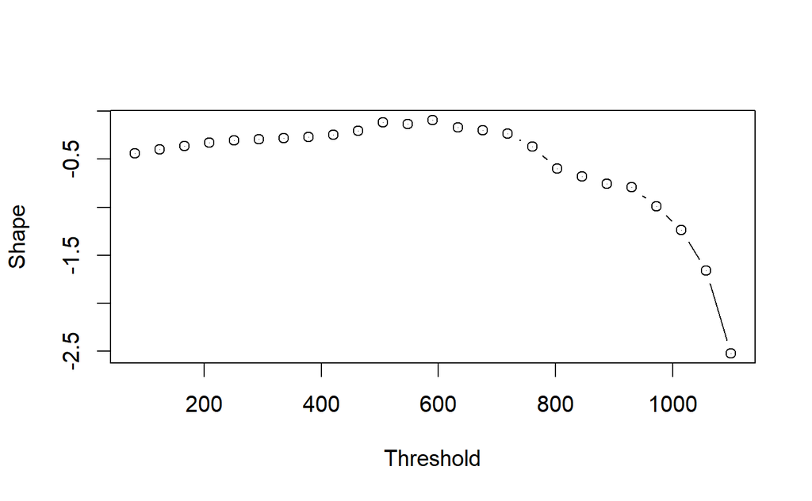

```r
mrlplot(waiting$Average.Wait.Seconds,umin = min(waiting$Average.Wait.Seconds), umax = max(waiting$Average.Wait.Seconds))

tlim <- c(81,1182)
tcplot(waiting$Average.Wait.Seconds, tlim = c(81,1100), std.err = FALSE)
```

Looking at the plot, we believe that the best threshold is at a value of 800. However, we are going to see if this holds true by analyzing the results in case we use a threshold of 600.

```r
u1 <- 600

u2 <- 800

waiting$col1 <- cut(waiting$Average.Wait.Seconds,
               breaks = c(-Inf, u1, Inf),
               labels = c("<=u", ">u"))

waiting$col2 <- cut(waiting$Average.Wait.Seconds,
               breaks = c(-Inf, u2, Inf),
               labels = c("<=u", ">u"))
```

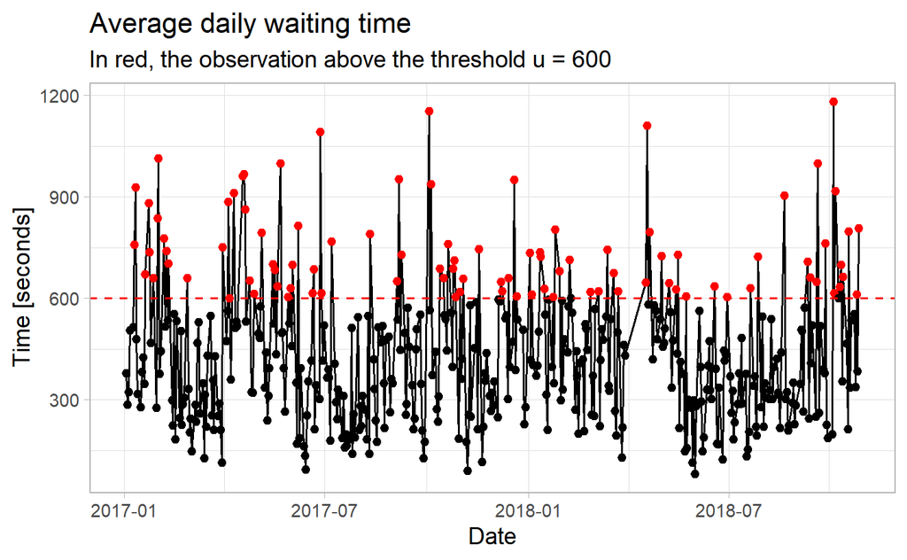

```r
waiting %>%
  ggplot() +
  geom_line(aes(Date, Average.Wait.Seconds)) +
  geom_point(aes(Date, Average.Wait.Seconds, color = col1)) +
  scale_colour_manual(values = c('black', 'red')) +
  geom_hline(yintercept = u1,
             linetype = 2,
             colour = "red") +
  guides(color = FALSE) +
  labs (x = "Date",
        y = "Time [seconds]",
        subtitle = "In red, the observation above the threshold u = 600",
        title = "Average daily waiting time")
```

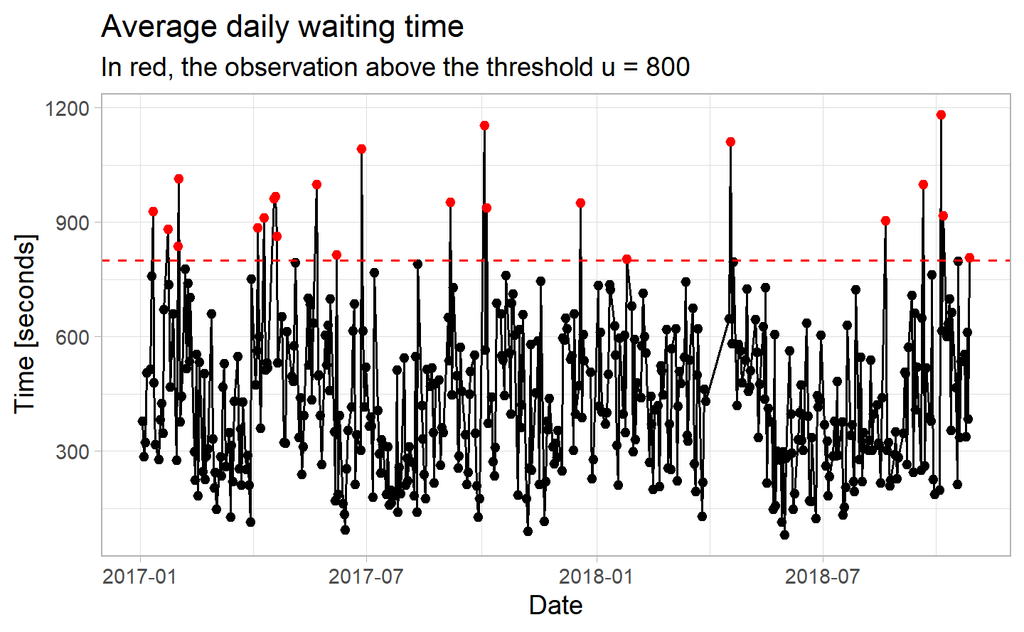

```r
waiting %>%
  ggplot() +
  geom_line(aes(Date, Average.Wait.Seconds)) +
  geom_point(aes(Date, Average.Wait.Seconds, color = col2)) +
  scale_colour_manual(values = c('black', 'red')) +
  geom_hline(yintercept = u2,
             linetype = 2,
             colour = "red") +
  guides(color = FALSE) +
    labs (x = "Date",
        y = "Time [seconds]",
        subtitle = "In red, the observation above the threshold u = 800",
        title = "Average daily waiting time")
```

We are going to fit a GPD on the difference between the observations highleted in the red dots and the thresholds. Once, using a threshold of 800 and then, of 600.

## part d - modelling the extremes

### Block Maxima

Monthly :

```r
# fitting the GEV to the maxima in order to have the location, scale and shape parameterss
fit_gev_maxima_monthly <- fgev(maxima_monthly$Average.Wait.Seconds)
fit_gev_maxima_monthly
```

```
#>
#> Call: fgev(x = maxima_monthly$Average.Wait.Seconds)
#> Deviance: 284
#>
#> Estimates
#>     loc    scale    shape
#> 831.743  144.635   -0.202
#>
#> Standard Errors
#>    loc   scale   shape
#> 38.518  30.520   0.273
#>
#> Optimization Information
#>   Convergence: successful
#>   Function Evaluations: 119
#>   Gradient Evaluations: 87
```

```r
shape <- fit_gev_maxima_monthly$estimate[3]
```

The estimates of the GEV show that the latter is a Weibull: indeed, the shape parameter is negative (-0.202).

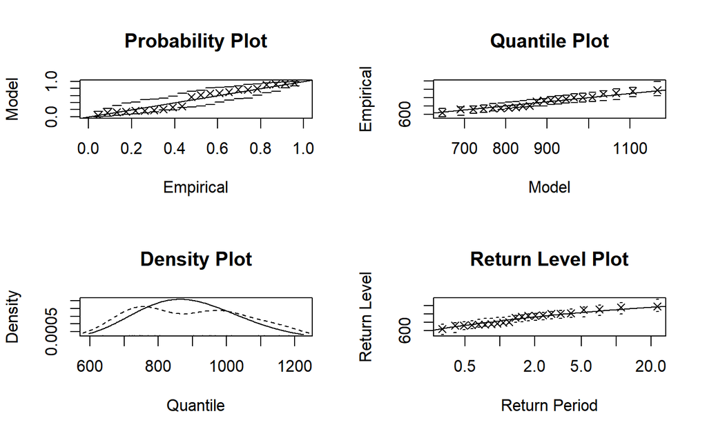

```r
par(mfrow = c(2,2))
plot(fit_gev_maxima_monthly)
```

Looking at the plot, we remark that if on the one hand the probability plot is not well fitted, on the other hand the observations almost perfectly fit the straight line in the qq-plot. Moreover, the Return Level Plot shows a function that is concave: this is a consequence of the negative shape parameter.

We are now going to make the same analysis but this time using the weekly maxima.

```r
fit_gev_maxima_weekly <- fgev(maxima_weekly$Average.Wait.Seconds)
fit_gev_maxima_weekly
```

```
#>
#> Call: fgev(x = maxima_weekly$Average.Wait.Seconds)
#> Deviance: 1236
#>
#> Estimates
#>     loc    scale    shape
#> 585.613  170.495   -0.126
#>
#> Standard Errors
#>     loc    scale    shape
#> 19.8480  14.0297   0.0748
#>
#> Optimization Information
#>   Convergence: successful
#>   Function Evaluations: 66
#>   Gradient Evaluations: 38
```

Once again, we have a shape parameter that is negative, meaning that we are still in a Weibull.

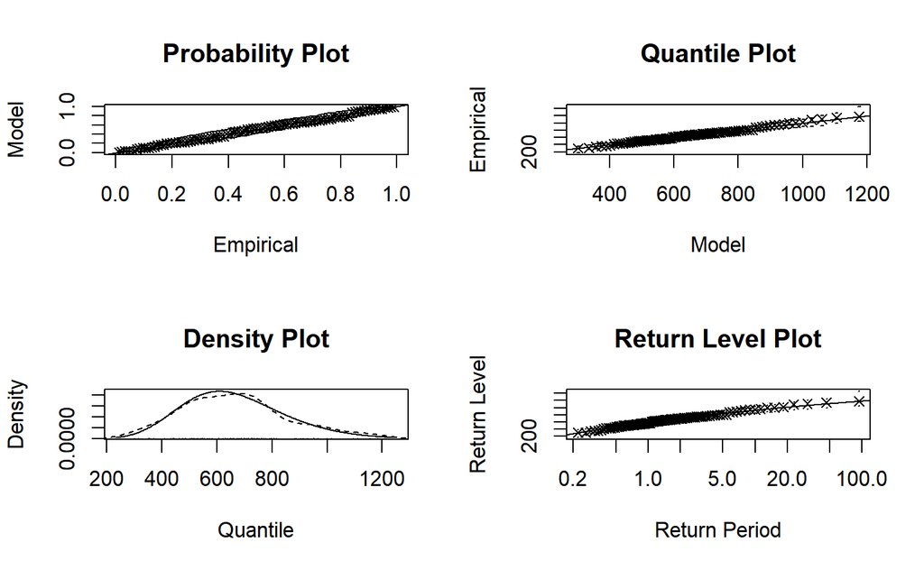

```r
par(mfrow = c(2,2))
plot(fit_gev_maxima_weekly)
```

Comparing the results between monthly blocks and weekly ones, we can clearly see that the results are better in the latter. Indeed, points are almost perfectly fitted for both the probability and quantile plot, which was not the case when we fitted the GEV to the monthly maxima. Thus, we can conclude that this for the block maxima approach the maxima from weekly blocks should be used.

### POT

```r
# fits the w = x - u to a gpd
fit_pot_u1 <-fpot(waiting$Average.Wait.Seconds, threshold = u1, model = c("gpd"))
fit_pot_u2 <-fpot(waiting$Average.Wait.Seconds, threshold = u2, model = c("gpd"))
```

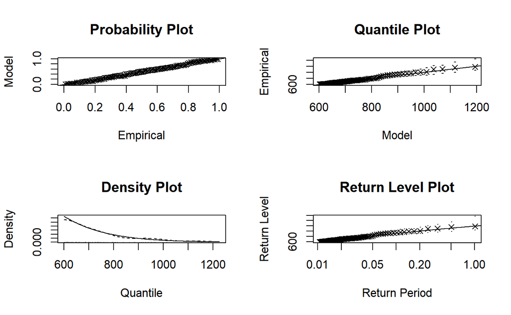

```r
par(mfrow=c(2,2))
plot(fit_pot_u1)
```

The plots above are the results of the analysis using a threhsold of 600. We can see that the output are good, meaning that the model is well fitted to our data. Moreover, we can observe that once again the Return Level Plot has a function that is concave, suggesting a negative shape parameter for the model.

We are now going to do the same analysis using a threshold of 800

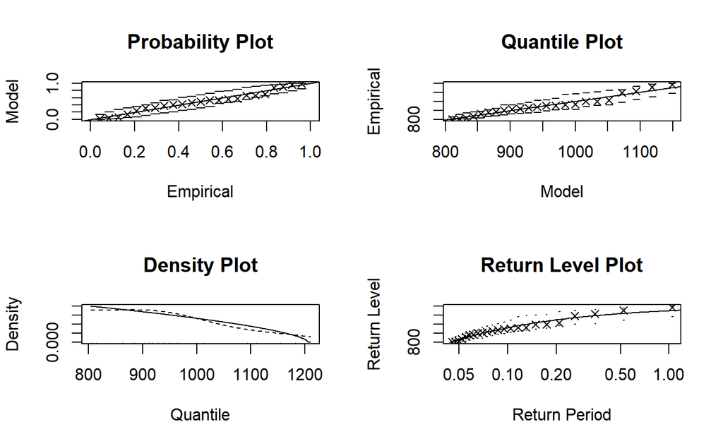

```r
par(mfrow=c(2,2))
plot(fit_pot_u2)
```

Naturally, having a higher threhsold the number of observations is lower. Looking at the results, we can conclude that we should select the threshold 600 since it allows having a better pp-plot and qq-plot.

## part e - upper control limit

### Block Maxima

Even if our dataset only consider the working days, we should use 365 days to compute the one year return level.

```r
# return level block maxima:
return_level_maxima <- fit_gev_maxima_weekly$estimate[1] + (fit_gev_maxima_weekly$estimate[2]/fit_gev_maxima_weekly$estimate[3])*(((-log(1-1/365))^-fit_gev_maxima_weekly$estimate[3])-1)

return_level <- return_level_maxima[[1]]
return_level
```

```
#> [1] 1295
```

After one year, we expect the Average waiting time in seconds to be of 1295.333 seconds.

### POT

Confidence Line

```r
n.survivors <- waiting %>%
  filter(Average.Wait.Seconds > u1) %>%
  summarize(n = n()) %>%
  pull(n)

p.survivors <- n.survivors/length(waiting$Average.Wait.Seconds)

confidence_line <- u1 + fit_pot_u1$estimate[1]/fit_pot_u1$estimate[2] * (((1-p)/p.survivors)^-fit_pot_u1$estimate[2]-1)

confidence_line[[1]]
```

```
#> [1] 1129
```

We expect the confidence line to be at 1128.807.